# Red Wine Quality Analysis

### Which chemical properties influence the quality of red wines?

By Linjing Yang

# Introduction

The tidy data set contains 1,599 red wines [^1] with 11 variables on the chemical properties of the wine. At least 3 wine experts rated the quality of each wine, providing a rating between 0 (very bad) and 10 (very excellent).

- 1599 records
- 11 chemical properties
- quality rating: 0 - 10

## Variables

### Input variables (based on physicochemical tests):

1. fixed acidity (tartaric acid - g / dm^3)
2. volatile acidity (acetic acid - g / dm^3)
3. citric acid (g / dm^3)
4. residual sugar (g / dm^3)
5. chlorides (sodium chloride - g / dm^3
6. free sulfur dioxide (mg / dm^3)
7. total sulfur dioxide (mg / dm^3)
8. density (g / cm^3)
9. pH
10. sulphates (potassium sulphate - g / dm3)
11. alcohol (% by volume)

### Output variable (based on sensory data):

12. quality (score between 0 and 10)

# Exploration of Data

| fixed.acidity | volatile.acidity | citric.acid | residual.sugar | chlorides | free.sulfur.dioxide | total.sulfur.dioxide | density | pH | sulphates | alcohol | quality |
| --- | --- | --- | --- | --- | --- | --- | --- | --- | --- | --- | --- |
| 7.4 | 0.70 | 0.00 | 1.9 | 0.076 | 11 | 34 | 0.9978 | 3.51 | 0.56 | 9.4 | 5 |
| 7.8 | 0.88 | 0.00 | 2.6 | 0.098 | 25 | 67 | 0.9968 | 3.20 | 0.68 | 9.8 | 5 |
| 7.8 | 0.76 | 0.04 | 2.3 | 0.092 | 15 | 54 | 0.9970 | 3.26 | 0.65 | 9.8 | 5 |
| 11.2 | 0.28 | 0.56 | 1.9 | 0.075 | 17 | 60 | 0.9980 | 3.16 | 0.58 | 9.8 | 6 |
| 7.4 | 0.70 | 0.00 | 1.9 | 0.076 | 11 | 34 | 0.9978 | 3.51 | 0.56 | 9.4 | 5 |
| 7.4 | 0.66 | 0.00 | 1.8 | 0.075 | 13 | 40 | 0.9978 | 3.51 | 0.56 | 9.4 | 5 |

## Univariate Plots

### Histogram of All the Variables

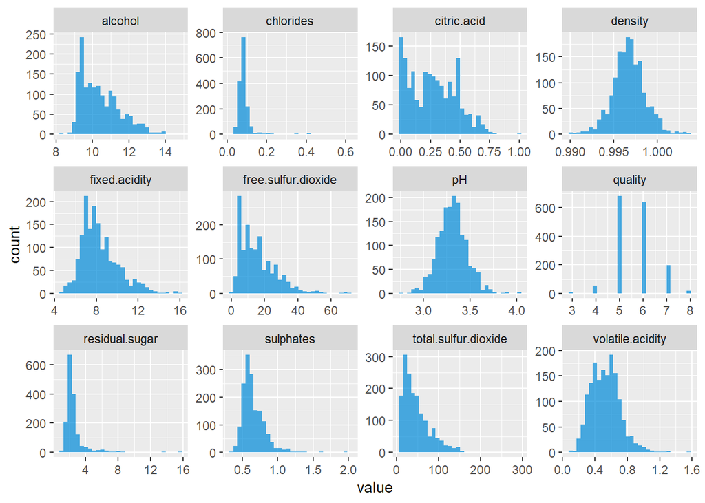

### Quality (Rating 0 - 10)

```
##    Min. 1st Qu.  Median    Mean 3rd Qu.    Max.
##   3.000   5.000   6.000   5.636   6.000   8.000
```

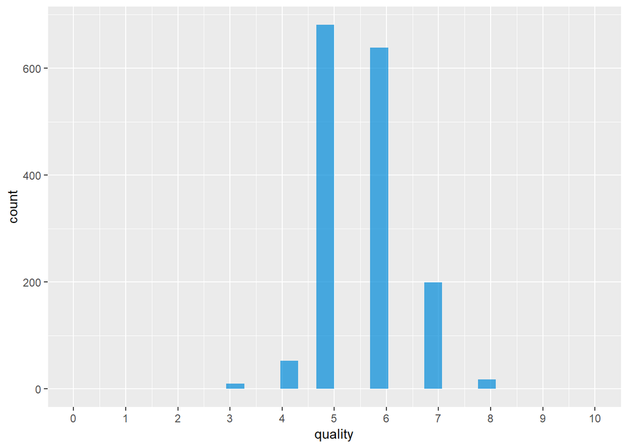

### Chemicals

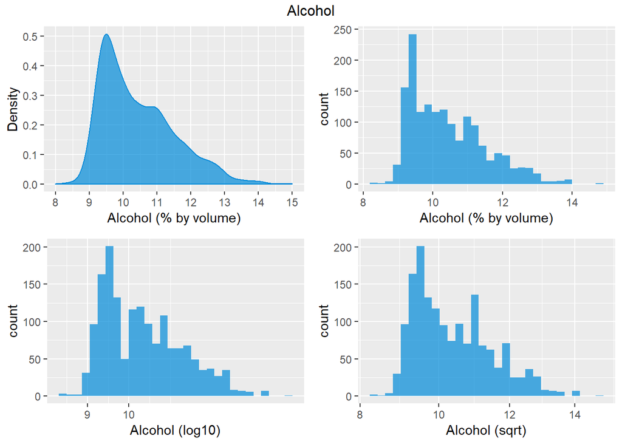

```
## Alcohol
##    Min. 1st Qu.  Median    Mean 3rd Qu.    Max.
##    8.40    9.50   10.20   10.42   11.10   14.90
```

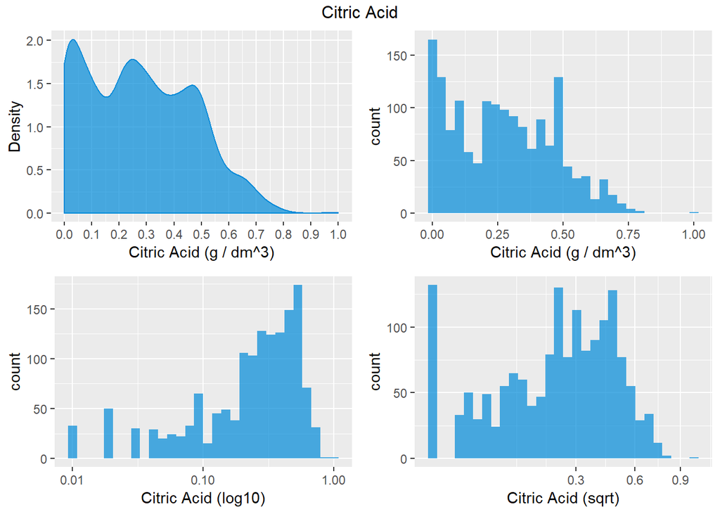

```
## Citric Acid
##    Min. 1st Qu.  Median    Mean 3rd Qu.    Max.
##   0.000   0.090   0.260   0.271   0.420   1.000
```

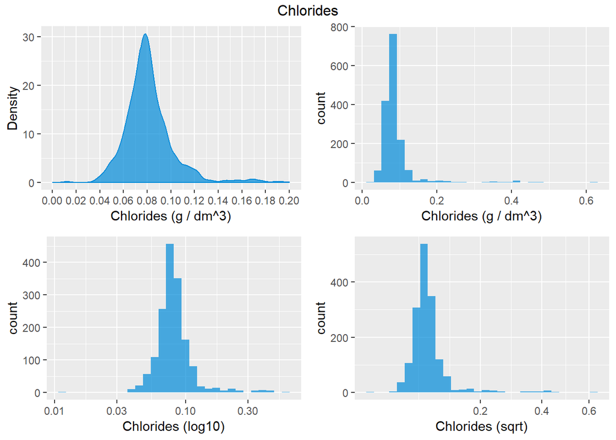

```
## Chlorides
##    Min. 1st Qu.  Median    Mean 3rd Qu.    Max.
## 0.01200 0.07000 0.07900 0.08747 0.09000 0.61100
```

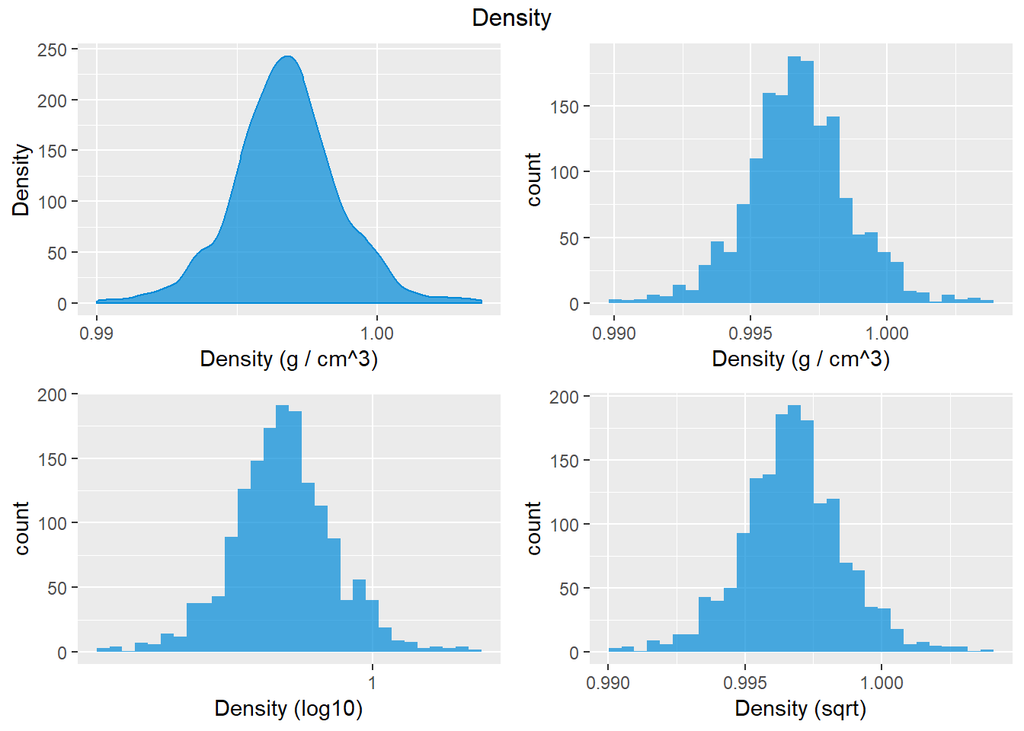

```
## Density
##    Min. 1st Qu.  Median    Mean 3rd Qu.    Max.
##  0.9901  0.9956  0.9968  0.9967  0.9978  1.0037
```

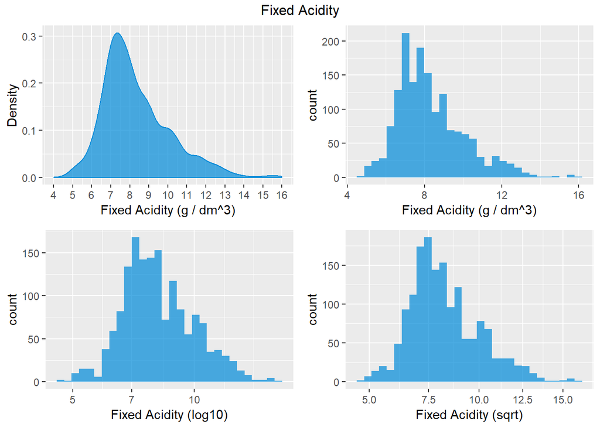

```
## Fixed Acidity
##    Min. 1st Qu.  Median    Mean 3rd Qu.    Max.
##    4.60    7.10    7.90    8.32    9.20   15.90
```

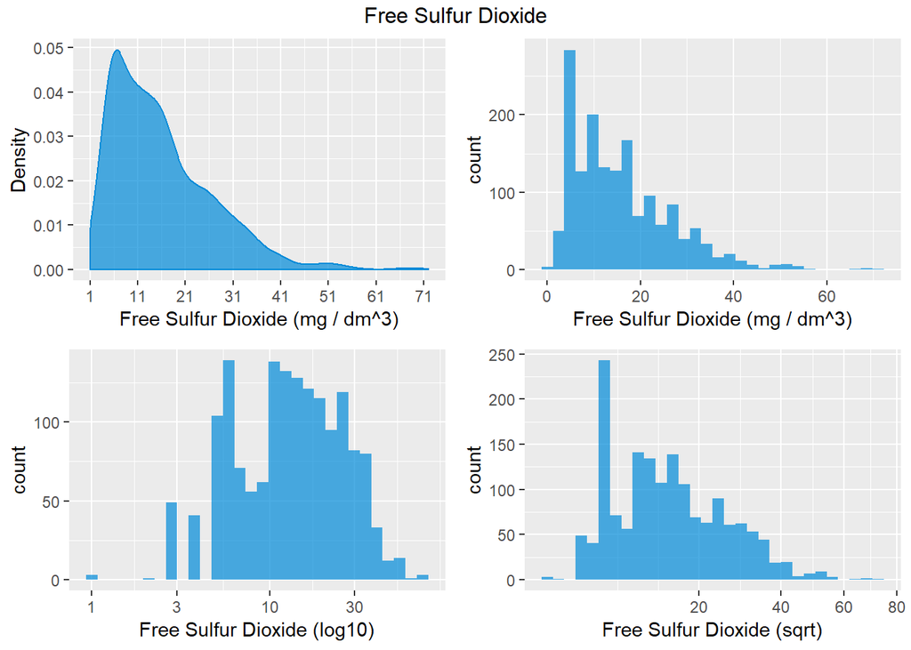

```
## Free Sulfur Dioxide
##    Min. 1st Qu.  Median    Mean 3rd Qu.    Max.
##    1.00    7.00   14.00   15.87   21.00   72.00
```

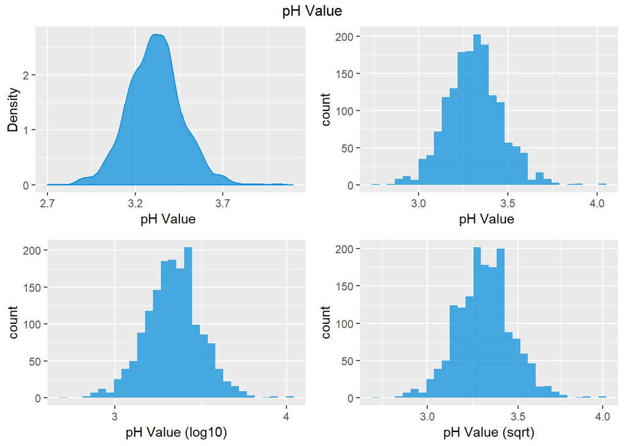

```
## pH Value
##    Min. 1st Qu.  Median    Mean 3rd Qu.    Max.
##   2.740   3.210   3.310   3.311   3.400   4.010
```

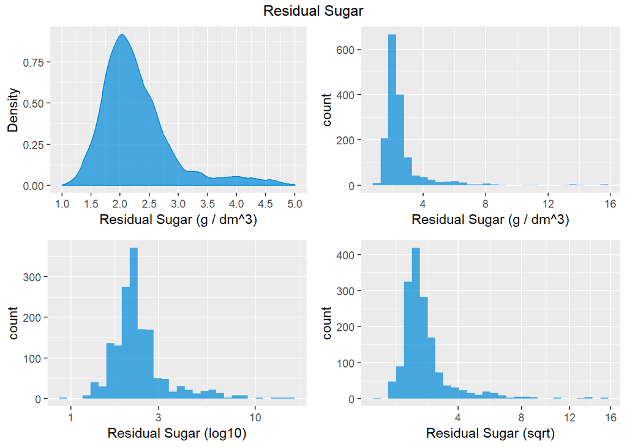

```
## Residual Sugar
##    Min. 1st Qu.  Median    Mean 3rd Qu.    Max.
##   0.900   1.900   2.200   2.539   2.600  15.500
```

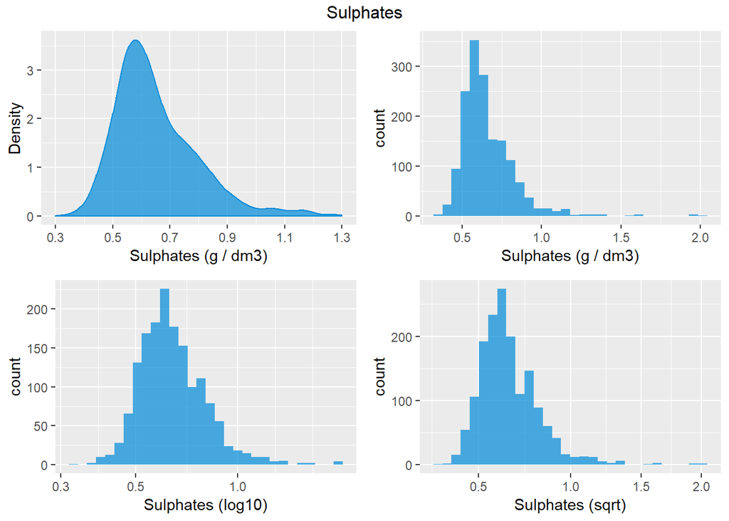

```
## Sulphates
##    Min. 1st Qu.  Median    Mean 3rd Qu.    Max.
##  0.3300  0.5500  0.6200  0.6581  0.7300  2.0000
```

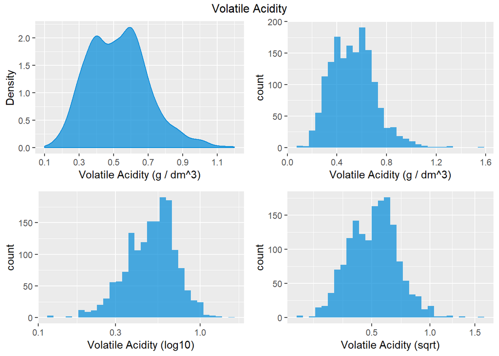

```
## Volatile Acidity
##    Min. 1st Qu.  Median    Mean 3rd Qu.    Max.
##  0.1200  0.3900  0.5200  0.5278  0.6400  1.5800
```

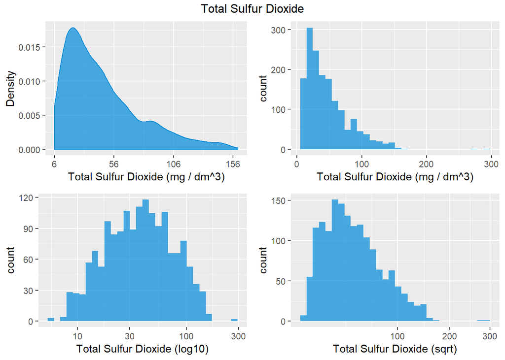

```
## Total Sulfur Dioxide
##    Min. 1st Qu.  Median    Mean 3rd Qu.    Max.
##    6.00   22.00   38.00   46.47   62.00  289.00
```

## Bivariate Plots

### Plots: Quality vs Chemicals

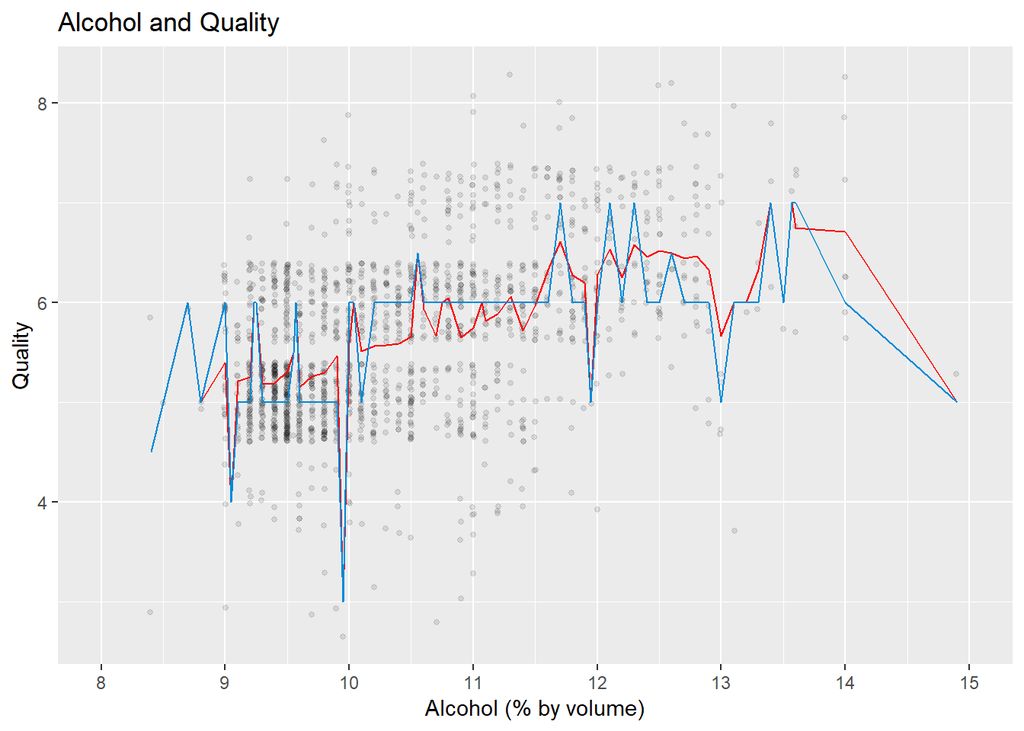

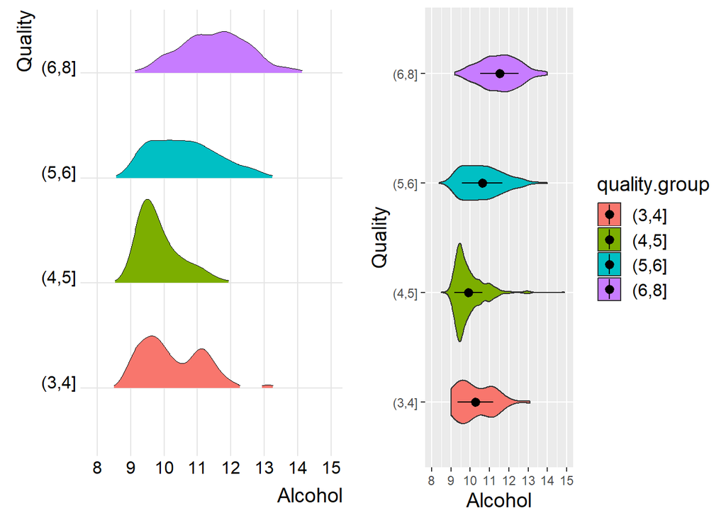

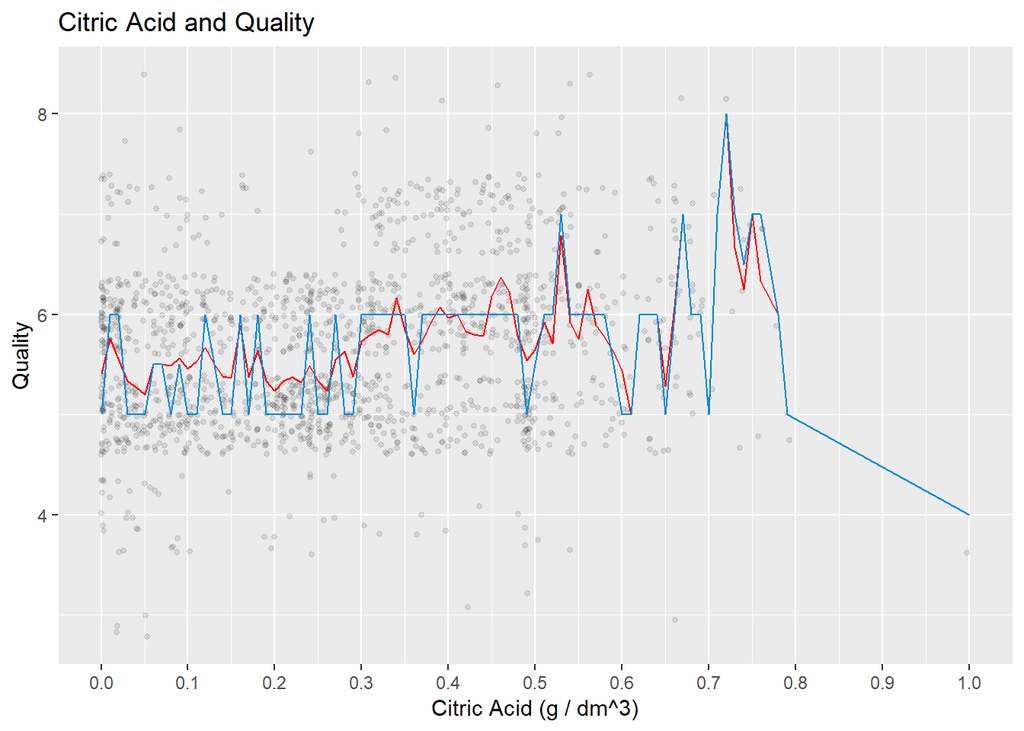

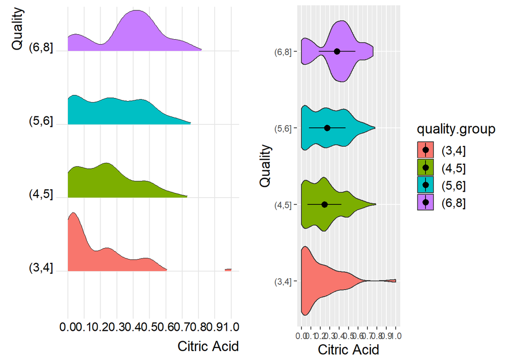

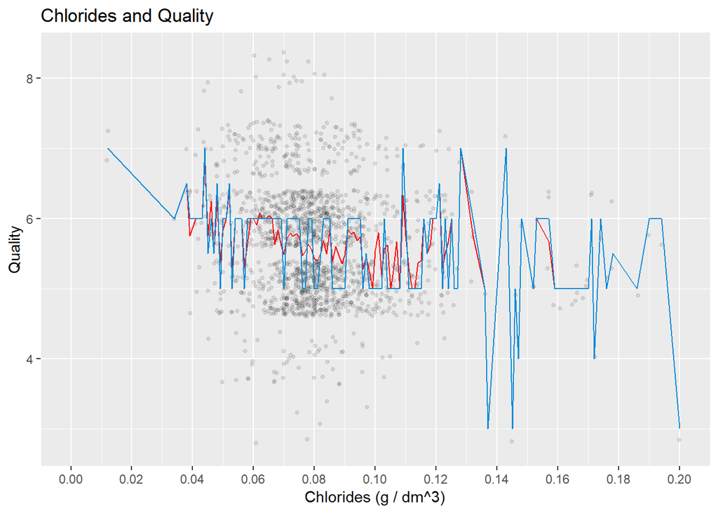

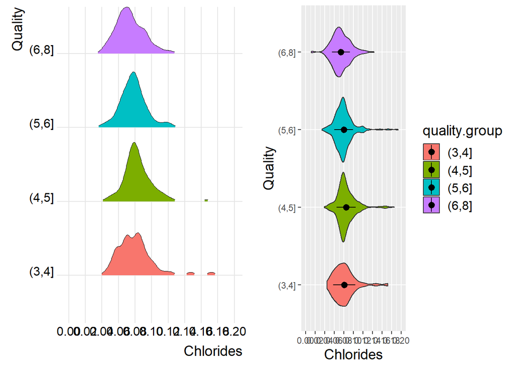

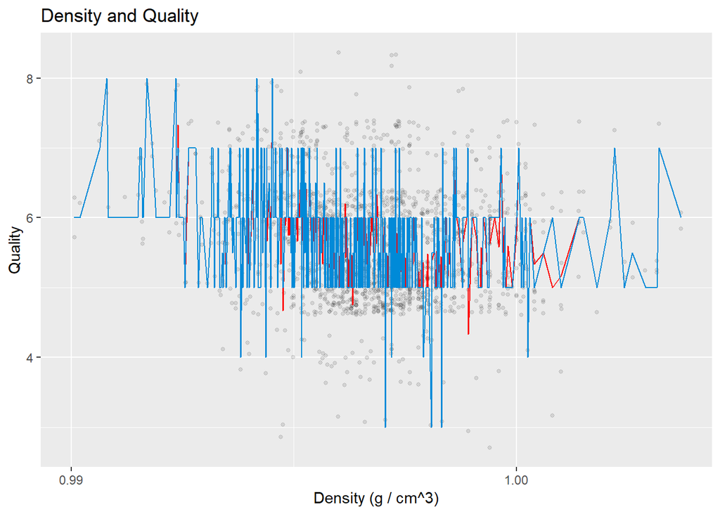

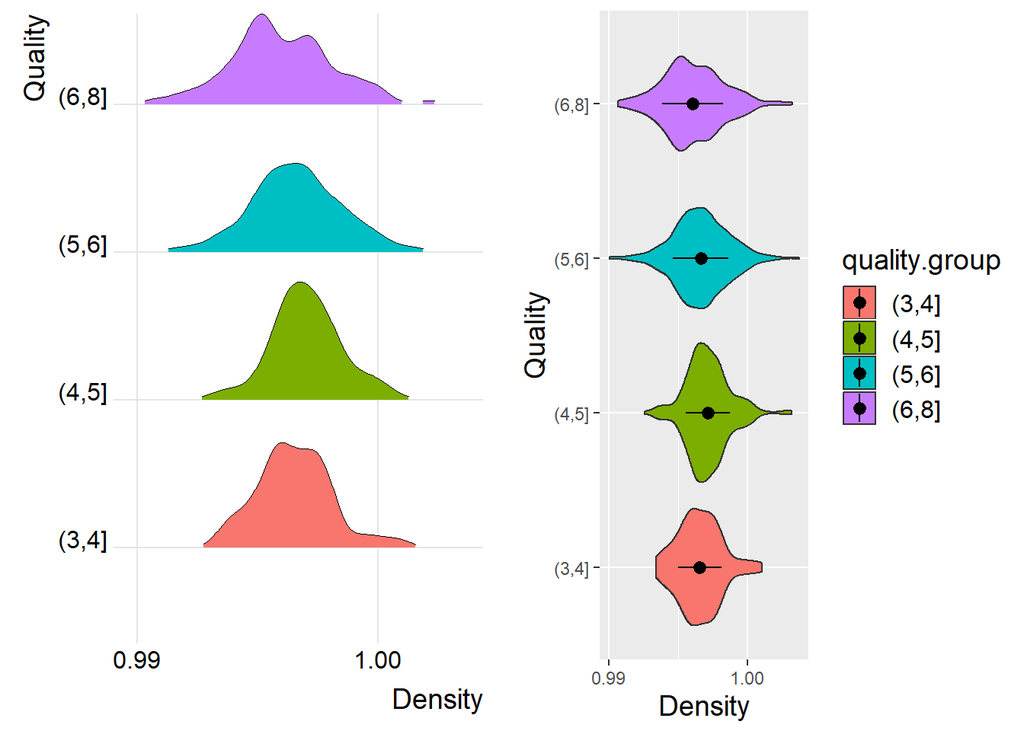

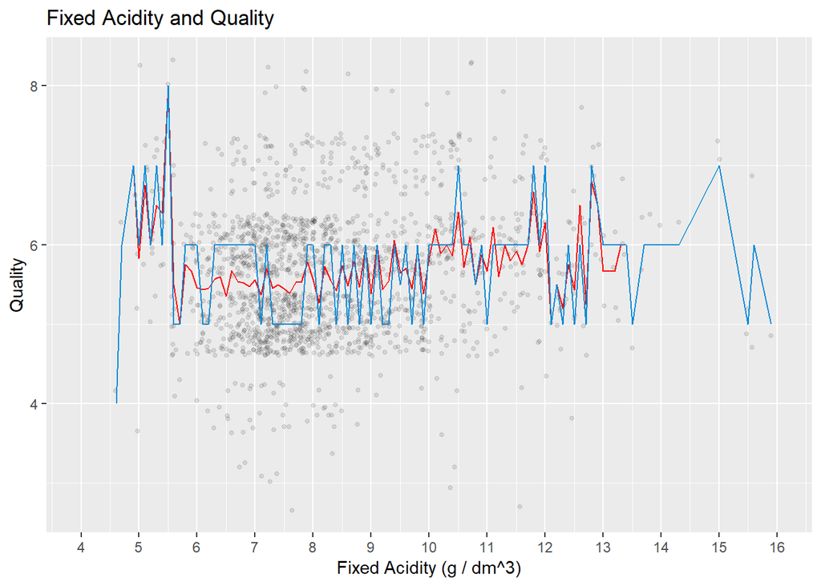

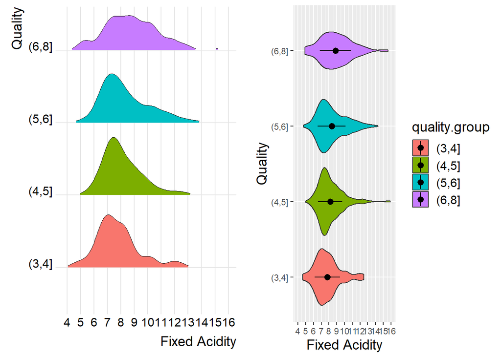

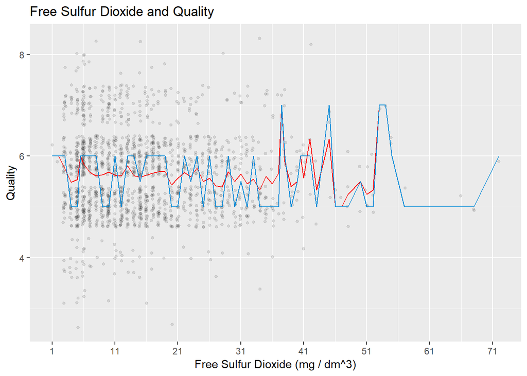

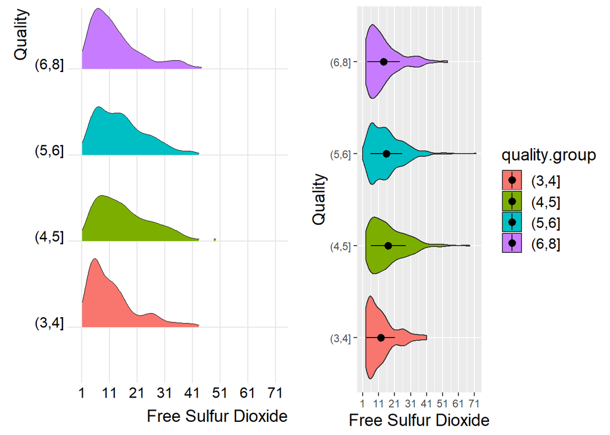

[10 more figures not shown]

From the plots above, we can find that there are 3 chemicals correlated with quality:

- Volatile Acidity: negative
- Sulphates: positive
- Alcohol: positive

### Spearman Correlation Coefficience: Quality vs Chemicals

| chemicals | r |
| --- | --- |
| Alcohol | 0.4785317 |
| Volatile Acidity | -0.3806465 |
| Sulphates | 0.3770602 |
| Citric Acid | 0.2134809 |
| Total Sulfur Dioxide | -0.1967351 |
| Chlorides | -0.1899223 |
| Density | -0.1770741 |
| Fixed Acidity | 0.1140837 |
| Free Sulfur Dioxide | -0.0569006 |
| pH Value | -0.0436719 |
| Residual Sugar | 0.0320482 |

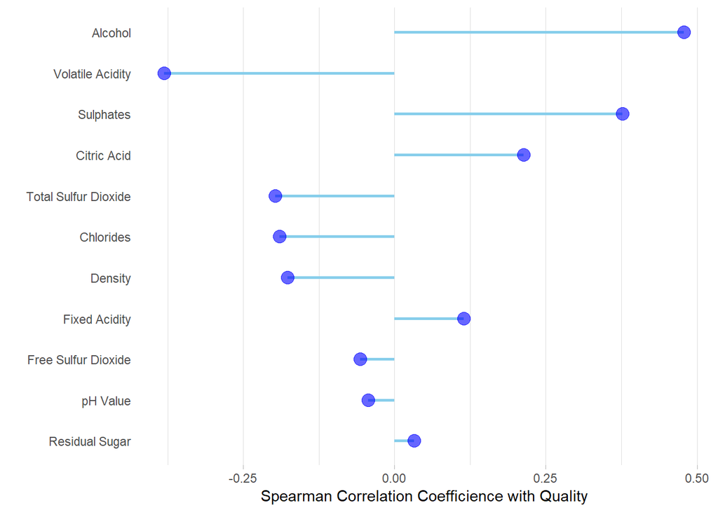

- Alcohol, Volatile Acidity and Sulphates are moderately correlated with quality.
- Other chemicals are not correlated with quality.

## Multivariate Plots - Chemicals

### Correlation

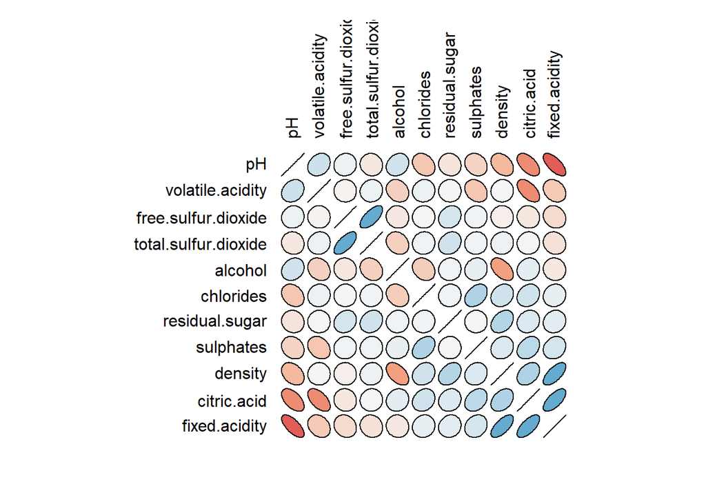

### Pearson Correlation Coefficient between Chemicals

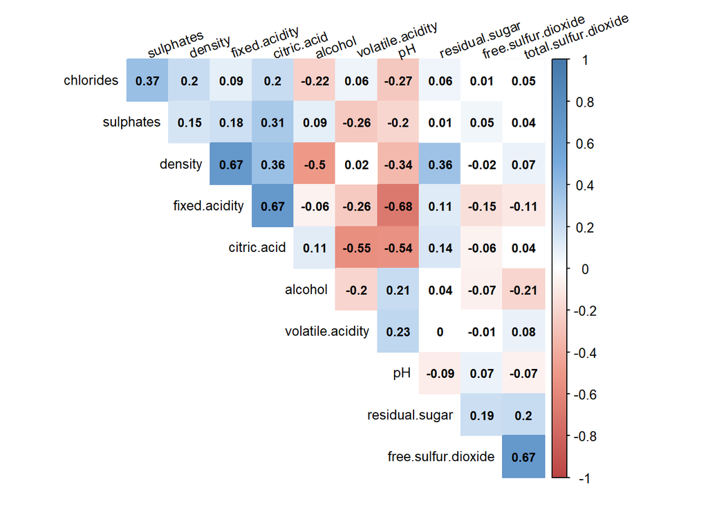

The three chemicals that are moderately correlated with quality - Alcohol, Volatile Acidity and Sulphates, are not correlate with each other.

High Correlation:

- pH v.s Fixed Acidity
- pH v.s. Citric Aciity
- Citric Acid v.s. Fixed Acidity
- Citric Acidity v.s. Volatile Acidity
- Density v.s. Fixed Acidity
- Free Sulfur Dioxide v.s. Total Sulfur Dioxide

### Moderately / Highly Correlated Chemicals

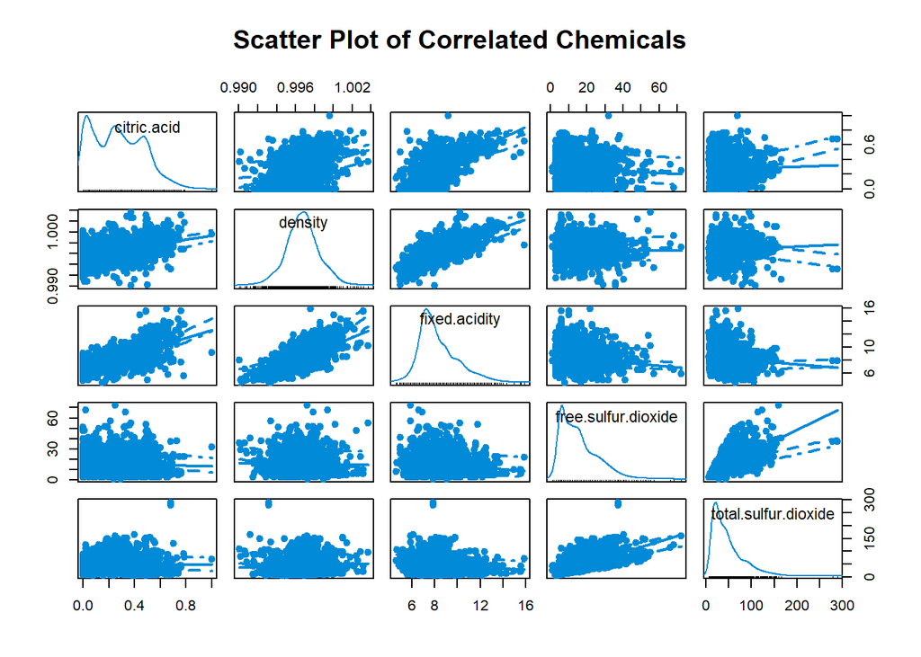

### Plots: PH, Fixed Acidity & Density

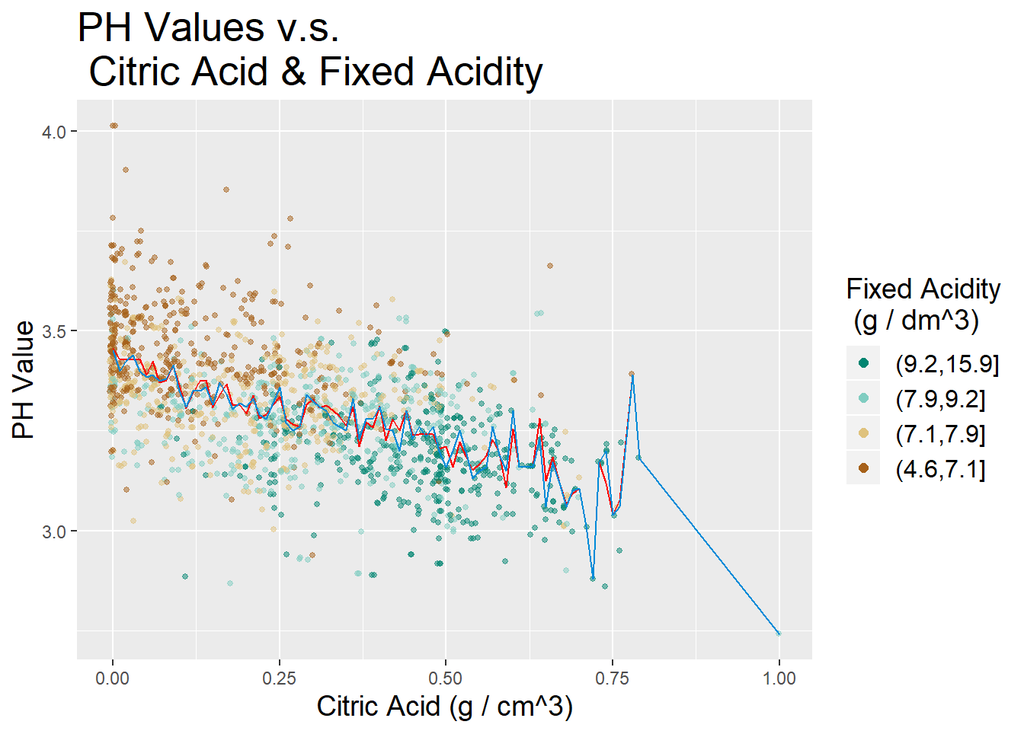

- Citric Acid and pH values are negatively correlated.
- Fixed acidity and pH values are negatively correlated.
- Fixed acidity and density values are positively correlated.

## Multivariate Plots - Quality v.s. Chemicals

3 chemicals are correlated with quality:

- Volatile Acidity: negative
- Sulphates: positive
- Alcohol: positive

From the correlation matrix above, it can be found that these 3 chemicals are not correlated with each other. Thus, they independently affect quality scores.

### Quality, Alcohol and Volatile Acidity

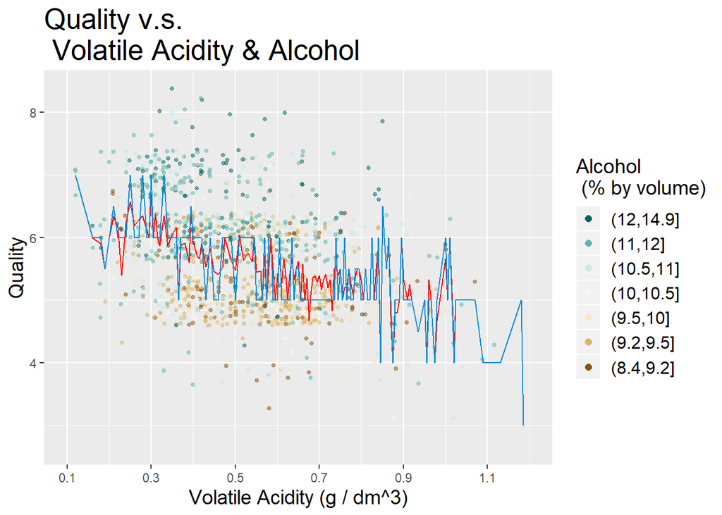

- Alcohol and quality are positively correlated.
- Volatile acidity and quality are negatively correlated.

### Quality, Alcohol and Sulphates

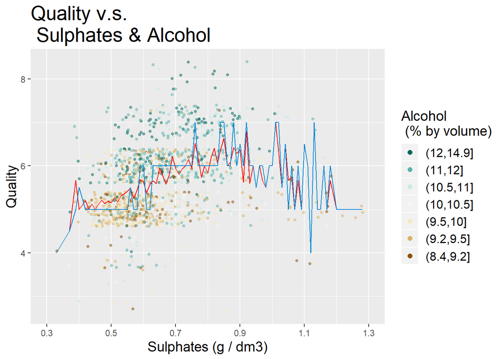

- Alcohol and quality are positively correlated.
- Sulphates and quality are positively correlated.